# Selekcja wyników z analizy PISA

Paulina Przybyłek & Przemysław Chojecki

7 listopada 2019

## Wykresy na plakat

Wykres 1. Przedstawia kraje o najlepszym systemie szkolnictwa uznanym przez ranking https://worldtop20.org/. Na wyniki tego rankingu wpływ mają:

- the Organisation for Economic Co-operation and Development (OECD),
- Programme for International Student Assessment (PISA),
- the United Nation’s Economic and Social Council (UNESOC),
- The Economist Intelligence Unit (EIU),
- the Trends in International Mathematics and Science Study (TIMSS),
- Progress in International Reading Study (PIRLS).

W 2016 UK zajęło miejsce 6.

[figure not shown]

Zamysł historii: Wyniki wielu krajów są lepsze niż w UK (mediana), jednak UK zajmuje 6. miejsce, więc warto się przyjrzeć bliżej jego szkolnictwu.

Wykres 2: Szkoły w Wielkiej Brytanii dzielą się względem uzyskiwanego funduszu na prowadzenie szkoły.

- Nizależne - szkoły posiadające *własny program nauczania*, niezależne od wpływu państwa, *prywatne*
- Akademie - sponsorowane przez państwo, *publiczne*
- Utrzymywane - sposorowane przez władze lokalne, *publiczne* jak i *prywatne*

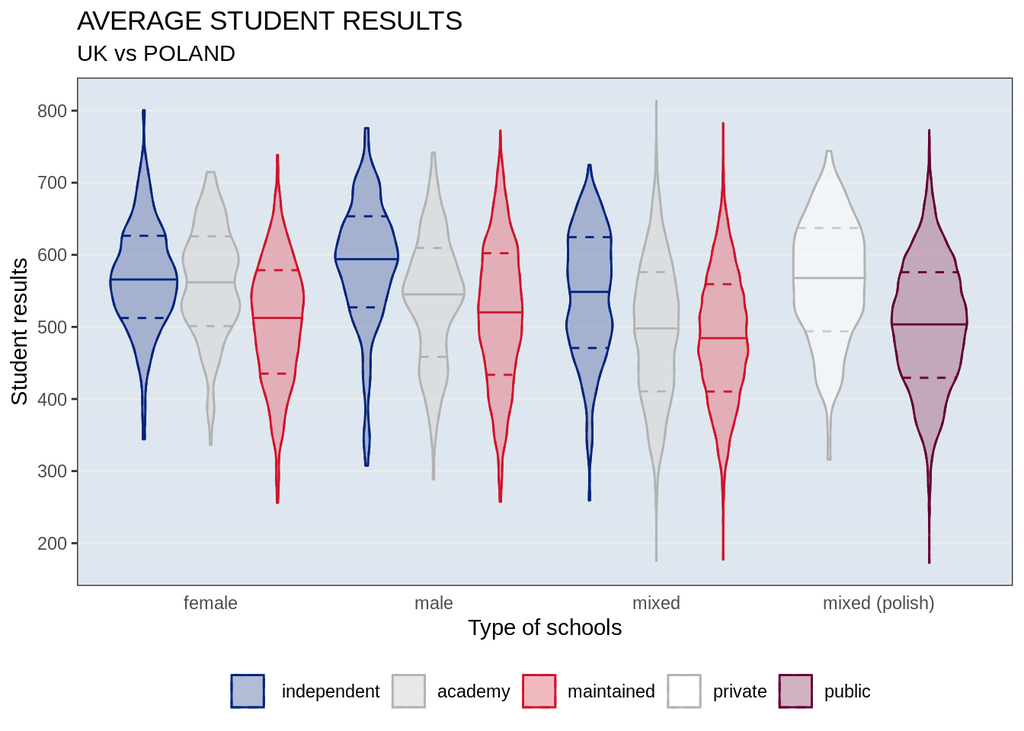

#### TODO

Czemu akademie są lepsze z publicznych?  
Czemu szkoły prywatne są lepsze - jacy są uczniowie w tych szkołach - porównanie?  
Wybrać trzy wykresy ciekawe z porównań.